# Project 2. EFA

Lomatskiy Andrey and Pomogaev Dmitriy

20th May 2020

# Aim and Research Question

The aim of my research is to investigate what kind of issues exist in explaining math achievement of students of Grade 8 in USA. The data was taken from TIMMS 2015 studies, filtered by country. I have taken 9013 observations of 24 variables which are primarily dedicated to student’s attitude toward math science, teachers involvement and math abilities. These categories are constructed with a help of factor analysis. Next, I conducted regression analysis which explains math achievement of a student, it includes factor scores which were constructed on the basis of 24 variables, and also include 3 predictor variables which show gender, parents’ education, and whether a person was born in USA or not. **Research Question:** + Which latent factors influence the math achievement score of students in USA? **Hypotheses:** + Higher abilities in math science increase math achievement score of a student. + Students, whose parents’ have high level of education, have higher math achievement score than those, whose parents’ have lower level of education.

# Data Preparation

```r
library(foreign)
data <- read.spss("BSGUSAM6.sav", to.data.frame = TRUE, use.value.labels = TRUE)
```

Uploading the dataset and constructing a dataframe.

```r
library(dplyr)
data.short <- data[c("BSBM17A", "BSBM17B", "BSBM17C", "BSBM17D", "BSBM17E", "BSBM17F", "BSBM17G", "BSBM17H", "BSBM17I", "BSBM18A", "BSBM18B", "BSBM18C", "BSBM18D", "BSBM18E", "BSBM18F", "BSBM18G", "BSBM18H", "BSBM18I", "BSBM18J", "BSBM19A", "BSBM19B", "BSBM19C", "BSBM19D", "BSBM19E", "BSMMAT01", "ITSEX", "BSDGEDUP", "BSBG10A")]

data.short1 <- na.omit(data.short)
```

First, I selected variables which are necessary for further analysis. Second, I deleted all of the “na” observations in order to conduct Factor Analysis further.

```r
data.efa <- data.short1[c("BSBM17A", "BSBM17B", "BSBM17C", "BSBM17D", "BSBM17E", "BSBM17F", "BSBM17G", "BSBM17H", "BSBM17I", "BSBM18A", "BSBM18B", "BSBM18C", "BSBM18D", "BSBM18E", "BSBM18F", "BSBM18G", "BSBM18H", "BSBM18I", "BSBM18J", "BSBM19A", "BSBM19B", "BSBM19C", "BSBM19D", "BSBM19E")]

data.reg <- data.short1[c("BSMMAT01", "ITSEX", "BSBG10A", "BSDGEDUP")]
```

I divided dataset into two subsets, **data.efa** is used for factor analysis, **data.reg** is used for regression model (later I will include factor scores in this subset).

# Descriptive Statistics

## BSBM17A - Enjoy Learning Mathematics

```r
library(ggplot2)
summary(data.short1$BSBM17A)
```

```
##       Agree a lot    Agree a little Disagree a little    Disagree a lot
##              2527              3470              1591              1425
```

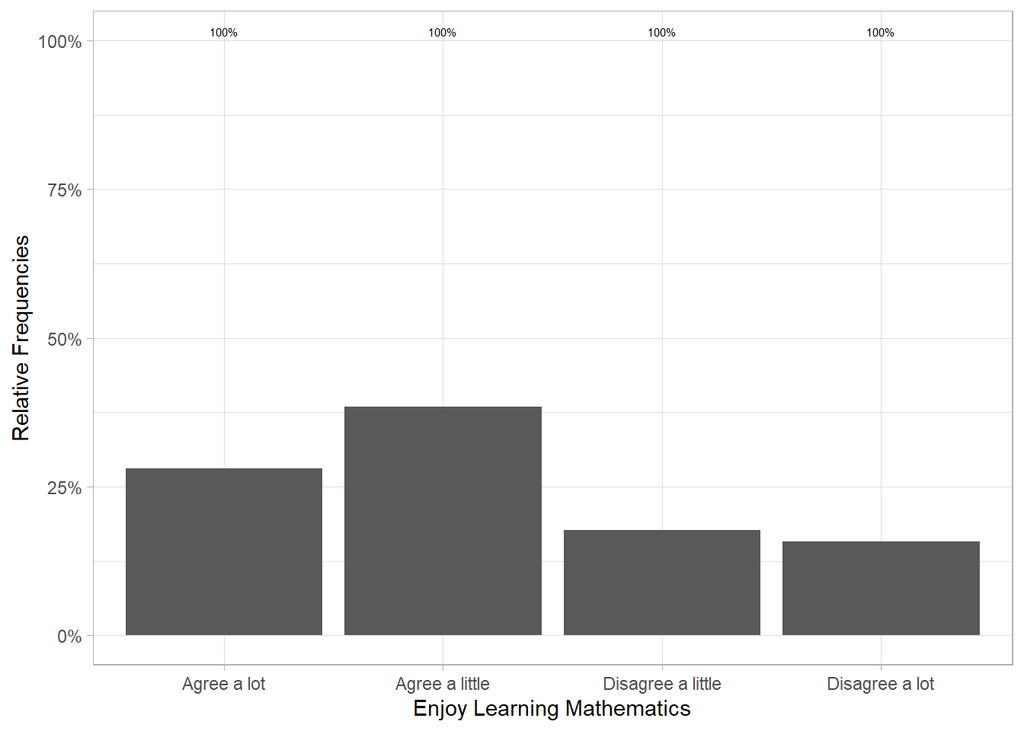

```r
ggplot(data = data.short1, aes (x = BSBM17A)) +
  geom_bar(aes(y=..count../sum(..count..))) +
  labs(x = "Enjoy Learning Mathematics") +
  scale_y_continuous(labels=scales::percent) +
  ylab("Relative Frequencies") +
  geom_text(aes( label = scales::percent(..prop..),
  y= ..prop.. ), stat= "count", vjust = -.5, size = 2) +
  theme(axis.title = element_text(size = 7), axis.text = element_text(size = 7)) +
  theme_light()
```

## BSBM17B - Wish Have Not Study Math

```r
summary(data.short1$BSBM17B)
```

```
##       Agree a lot    Agree a little Disagree a little    Disagree a lot
##              1927              2382              2323              2381
```

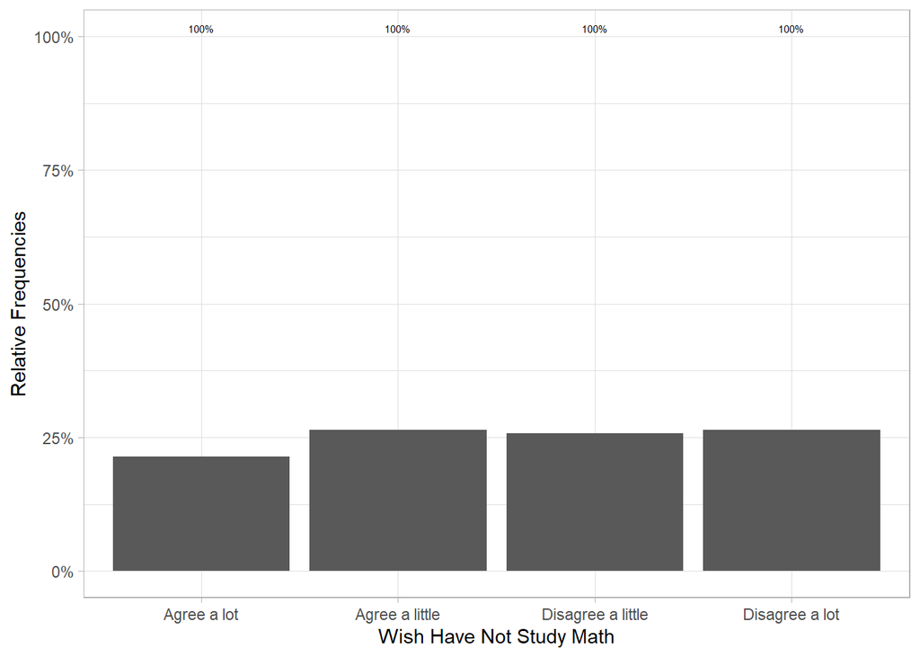

```r
ggplot(data = data.short1, aes (x = BSBM17B)) +
  geom_bar(aes(y=..count../sum(..count..))) +
  labs(x = "Wish Have Not Study Math") +
  scale_y_continuous(labels=scales::percent) +
  ylab("Relative Frequencies") +
  geom_text(aes( label = scales::percent(..prop..),
  y= ..prop.. ), stat= "count", vjust = -.5, size = 2) +
  theme(axis.title = element_text(size = 7), axis.text = element_text(size = 7)) +
  theme_light()
```

## BSBM17C - Math Is Boring

```r
summary(data.short1$BSBM17C)
```

```
##       Agree a lot    Agree a little Disagree a little    Disagree a lot
##              2140              2804              2268              1801
```

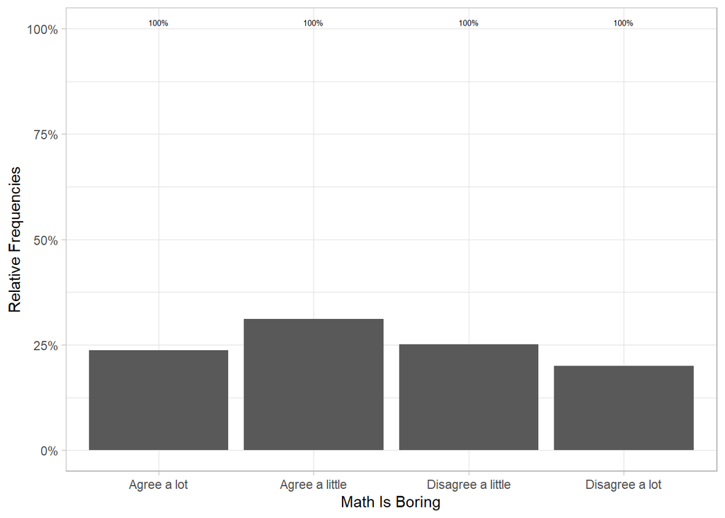

```r
ggplot(data = data.short1, aes (x = BSBM17C)) +
  geom_bar(aes(y=..count../sum(..count..))) +
  labs(x = "Math Is Boring") +
  scale_y_continuous(labels=scales::percent) +
  ylab("Relative Frequencies") +
  geom_text(aes( label = scales::percent(..prop..),
  y= ..prop.. ), stat= "count", vjust = -.5, size = 2) +
  theme(axis.title = element_text(size = 7), axis.text = element_text(size = 7)) +
  theme_light()
```

## BSBM17D - Learn Interesting Things

```r
summary(data.short1$BSBM17D)
```

```
##       Agree a lot    Agree a little Disagree a little    Disagree a lot
##              2628              3450              1944               991
```

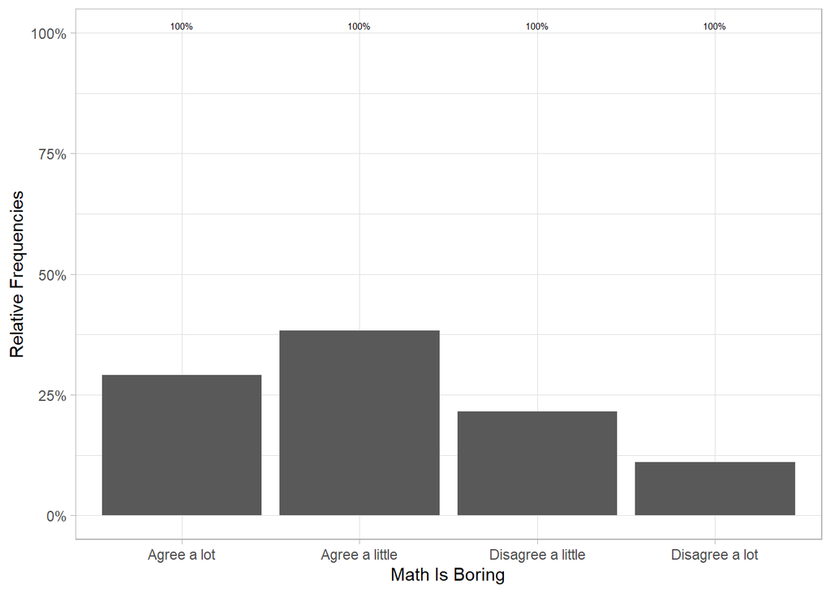

```r
ggplot(data = data.short1, aes (x = BSBM17D)) +
  geom_bar(aes(y=..count../sum(..count..))) +
  labs(x = "Math Is Boring") +
  scale_y_continuous(labels=scales::percent) +
  ylab("Relative Frequencies") +
  geom_text(aes( label = scales::percent(..prop..),
  y= ..prop.. ), stat= "count", vjust = -.5, size = 2) +
  theme(axis.title = element_text(size = 7), axis.text = element_text(size = 7)) +
  theme_light()
```

## BSBM17E - Like Mathematics

```r
summary(data.short1$BSBM17E)
```

```
##       Agree a lot    Agree a little Disagree a little    Disagree a lot
##              2561              3052              1697              1703
```

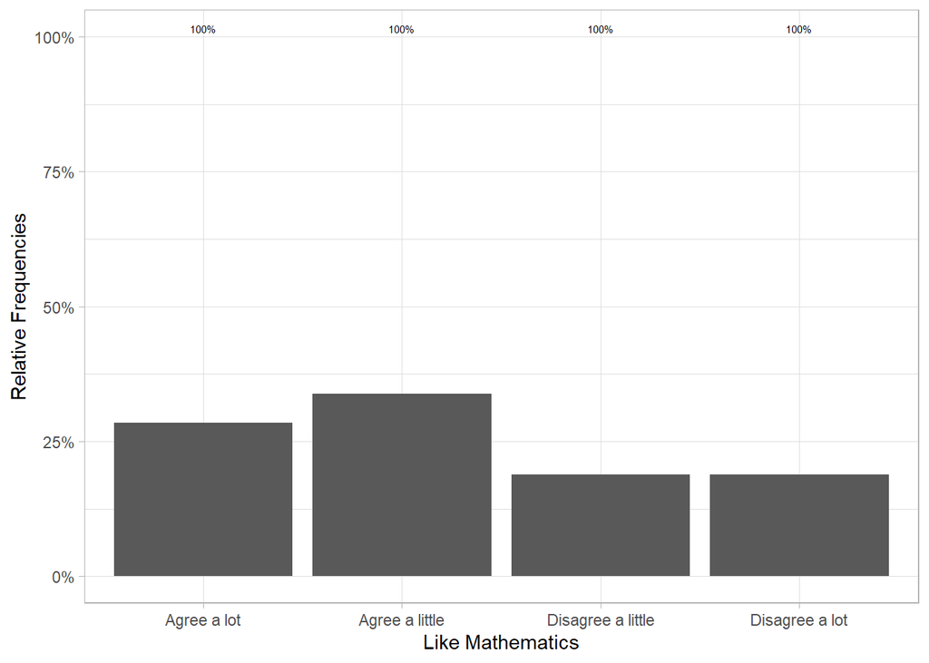

```r
ggplot(data = data.short1, aes (x = BSBM17E)) +
  geom_bar(aes(y=..count../sum(..count..))) +
  labs(x = "Like Mathematics") +
  scale_y_continuous(labels=scales::percent) +
  ylab("Relative Frequencies") +
  geom_text(aes( label = scales::percent(..prop..),
  y= ..prop.. ), stat= "count", vjust = -.5, size = 2) +
  theme(axis.title = element_text(size = 7), axis.text = element_text(size = 7)) +
  theme_light()
```

## BSBM17F - Like Numbers

```r
summary(data.short1$BSBM17F)
```

```
##       Agree a lot    Agree a little Disagree a little    Disagree a lot
##              1194              2502              3095              2222
```

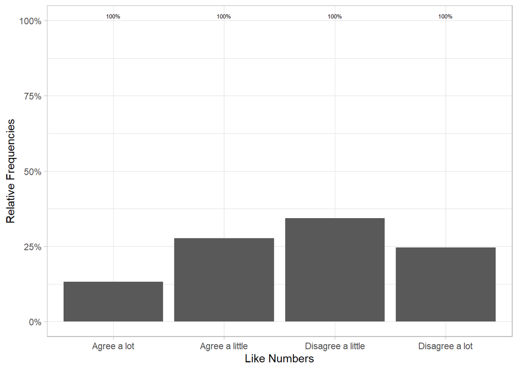

```r
ggplot(data = data.short1, aes (x = BSBM17F)) +
  geom_bar(aes(y=..count../sum(..count..))) +
  labs(x = "Like Numbers") +
  scale_y_continuous(labels=scales::percent) +
  ylab("Relative Frequencies") +
  geom_text(aes( label = scales::percent(..prop..),
  y= ..prop.. ), stat= "count", vjust = -.5, size = 2) +
  theme(axis.title = element_text(size = 7), axis.text = element_text(size = 7)) +
  theme_light()
```

## BSBM17G - Like Math Problems

```r
summary(data.short1$BSBM17G)
```

```
##       Agree a lot    Agree a little Disagree a little    Disagree a lot
##              1831              2785              2340              2057
```

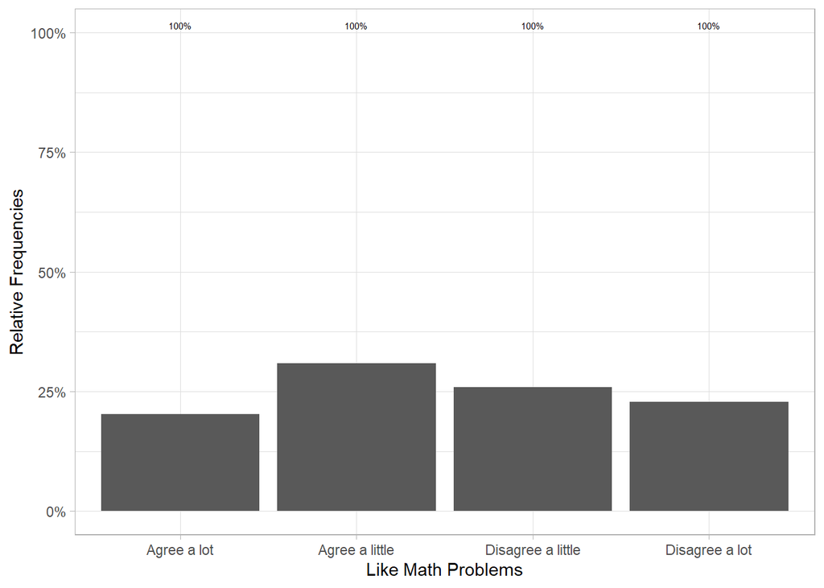

```r
ggplot(data = data.short1, aes (x = BSBM17G)) +
  geom_bar(aes(y=..count../sum(..count..))) +
  labs(x = "Like Math Problems") +
  scale_y_continuous(labels=scales::percent) +
  ylab("Relative Frequencies") +
  geom_text(aes( label = scales::percent(..prop..),
  y= ..prop.. ), stat= "count", vjust = -.5, size = 2) +
  theme(axis.title = element_text(size = 7), axis.text = element_text(size = 7)) +
  theme_light()
```

## BSBM17H - Look Forward to Math Class

```r
summary(data.short1$BSBM17H)
```

```
##       Agree a lot    Agree a little Disagree a little    Disagree a lot
##              1736              2497              2524              2256
```

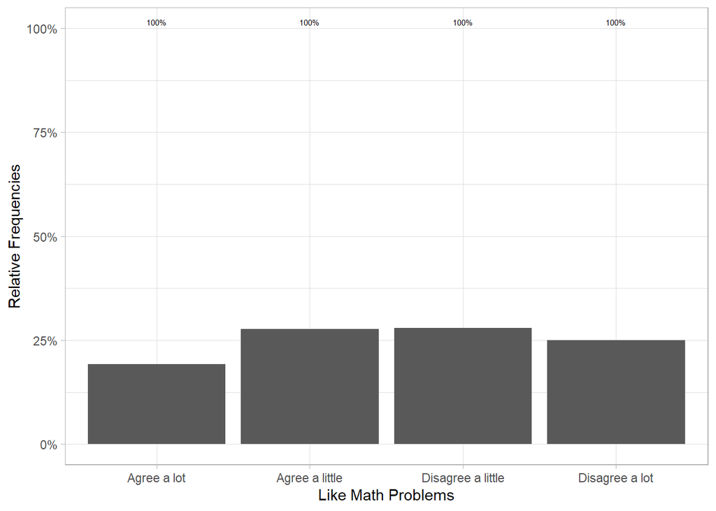

```r
ggplot(data = data.short1, aes (x = BSBM17H)) +
  geom_bar(aes(y=..count../sum(..count..))) +
  labs(x = "Like Math Problems") +
  scale_y_continuous(labels=scales::percent) +
  ylab("Relative Frequencies") +
  geom_text(aes( label = scales::percent(..prop..),
  y= ..prop.. ), stat= "count", vjust = -.5, size = 2) +
  theme(axis.title = element_text(size = 7), axis.text = element_text(size = 7)) +
  theme_light()
```

## BSBM17I - Favorite Subject

```r
summary(data.short1$BSBM17I)
```

```
##       Agree a lot    Agree a little Disagree a little    Disagree a lot
##              2431              1937              1821              2824
```

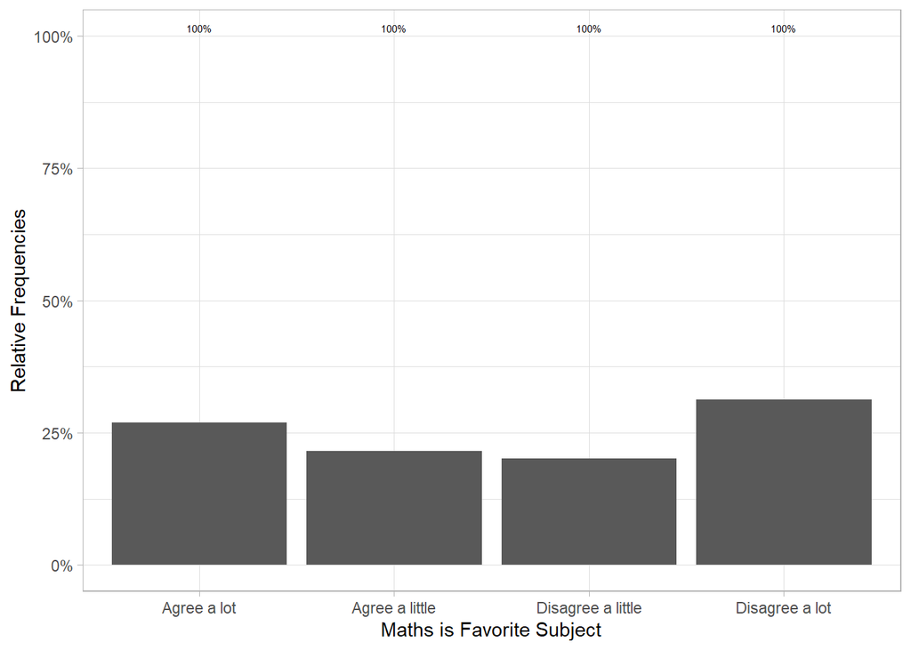

```r
ggplot(data = data.short1, aes (x = BSBM17I)) +
  geom_bar(aes(y=..count../sum(..count..))) +
  labs(x = "Maths is Favorite Subject") +
  scale_y_continuous(labels=scales::percent) +
  ylab("Relative Frequencies") +
  geom_text(aes( label = scales::percent(..prop..),
  y= ..prop.. ), stat= "count", vjust = -.5, size = 2) +
  theme(axis.title = element_text(size = 7), axis.text = element_text(size = 7)) +
  theme_light()
```

## BSBM18A - Teacher Expects To Do

```r
summary(data.short1$BSBM18A)
```

```
##       Agree a lot    Agree a little Disagree a little    Disagree a lot
##              5588              2698               555               172
```

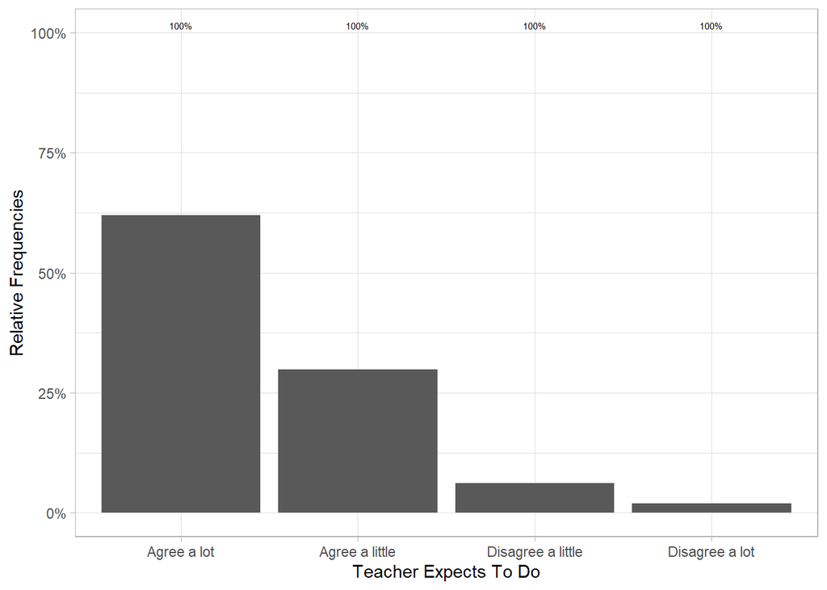

```r
ggplot(data = data.short1, aes (x = BSBM18A)) +
  geom_bar(aes(y=..count../sum(..count..))) +
  labs(x = "Teacher Expects To Do") +
  scale_y_continuous(labels=scales::percent) +
  ylab("Relative Frequencies") +
  geom_text(aes( label = scales::percent(..prop..),
  y= ..prop.. ), stat= "count", vjust = -.5, size = 2) +
  theme(axis.title = element_text(size = 7), axis.text = element_text(size = 7)) +
  theme_light()
```

## BSBM18B - Teacher Is Easy To Understand

```r
summary(data.short1$BSBM18B)
```

```
##       Agree a lot    Agree a little Disagree a little    Disagree a lot
##              3995              2949              1366               703
```

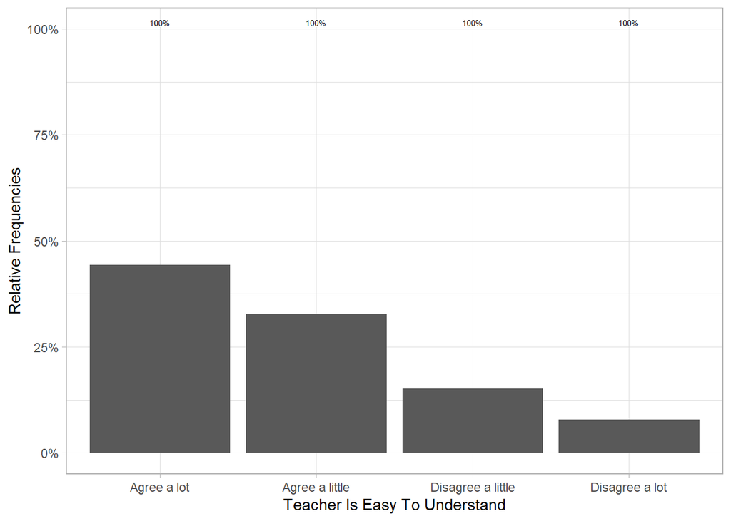

```r
ggplot(data = data.short1, aes (x = BSBM18B)) +
  geom_bar(aes(y=..count../sum(..count..))) +
  labs(x = "Teacher Is Easy To Understand") +
  scale_y_continuous(labels=scales::percent) +
  ylab("Relative Frequencies") +
  geom_text(aes( label = scales::percent(..prop..),
  y= ..prop.. ), stat= "count", vjust = -.5, size = 2) +
  theme(axis.title = element_text(size = 7), axis.text = element_text(size = 7)) +
  theme_light()
```

## BSBM18C - Interesred in What Teacher Says

```r
summary(data.short1$BSBM18C)
```

```
##       Agree a lot    Agree a little Disagree a little    Disagree a lot
##              2876              3391              1915               831
```

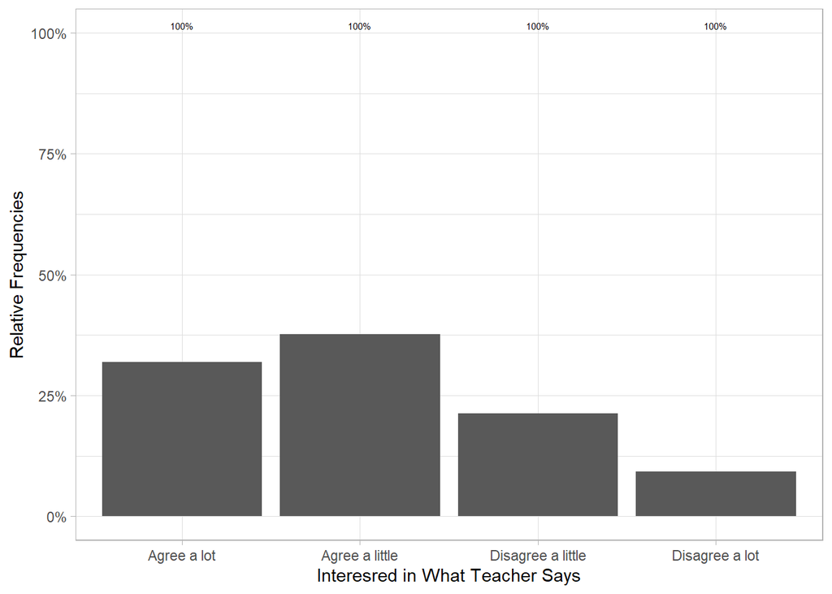

```r
ggplot(data = data.short1, aes (x = BSBM18C)) +
  geom_bar(aes(y=..count../sum(..count..))) +
  labs(x = "Interesred in What Teacher Says") +
  scale_y_continuous(labels=scales::percent) +
  ylab("Relative Frequencies") +
  geom_text(aes( label = scales::percent(..prop..),
  y= ..prop.. ), stat= "count", vjust = -.5, size = 2) +
  theme(axis.title = element_text(size = 7), axis.text = element_text(size = 7)) +
  theme_light()
```

## BSBM18D - Interesting Things To Do

```r
summary(data.short1$BSBM18D)
```

```
##       Agree a lot    Agree a little Disagree a little    Disagree a lot
##              2413              3169              2215              1216
```

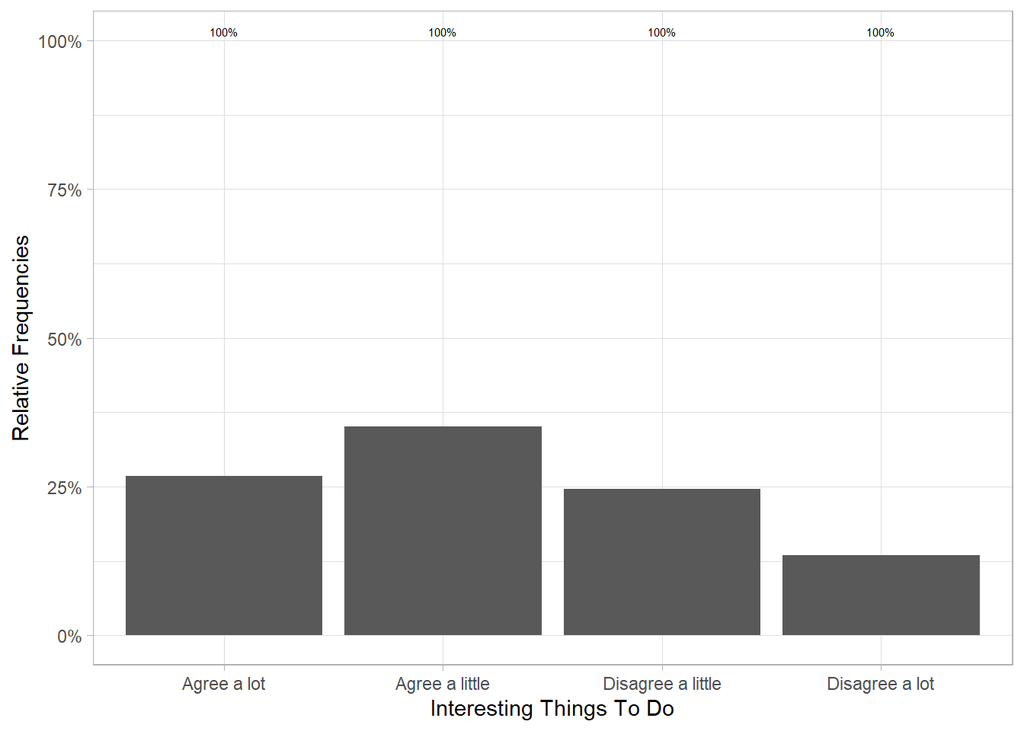

```r
ggplot(data = data.short1, aes (x = BSBM18D)) +
  geom_bar(aes(y=..count../sum(..count..))) +
  labs(x = "Interesting Things To Do") +
  scale_y_continuous(labels=scales::percent) +
  ylab("Relative Frequencies") +
  geom_text(aes( label = scales::percent(..prop..),
  y= ..prop.. ), stat= "count", vjust = -.5, size = 2) +
  theme(axis.title = element_text(size = 7), axis.text = element_text(size = 7)) +
  theme_light()
```

## BSBM18E - Teacher Clear Answers

```r
summary(data.short1$BSBM18E)
```

```
##       Agree a lot    Agree a little Disagree a little    Disagree a lot
##              3830              2813              1554               816
```

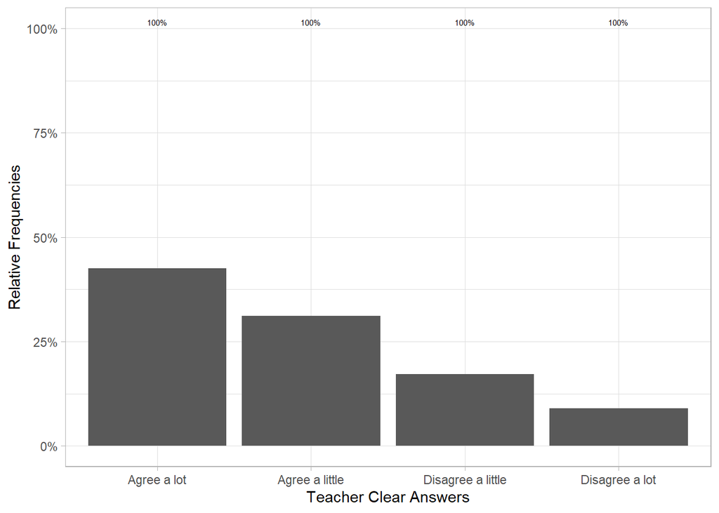

```r
ggplot(data = data.short1, aes (x = BSBM18E)) +
  geom_bar(aes(y=..count../sum(..count..))) +
  labs(x = "Teacher Clear Answers") +
  scale_y_continuous(labels=scales::percent) +
  ylab("Relative Frequencies") +
  geom_text(aes( label = scales::percent(..prop..),
  y= ..prop.. ), stat= "count", vjust = -.5, size = 2) +
  theme(axis.title = element_text(size = 7), axis.text = element_text(size = 7)) +
  theme_light()
```

## BSBM18F - Teacher Explains Good

```r
summary(data.short1$BSBM18F)
```

```
##       Agree a lot    Agree a little Disagree a little    Disagree a lot
##              4671              2487              1137               718
```

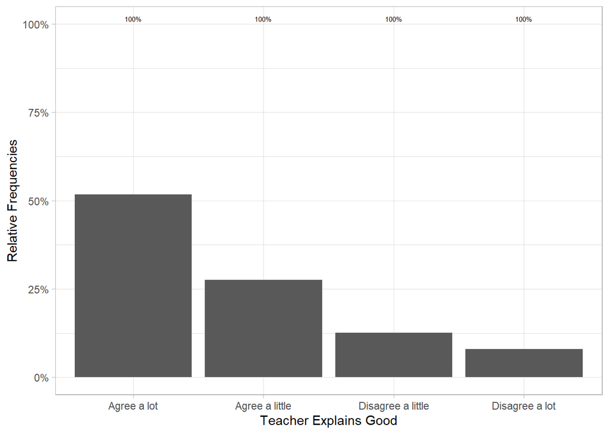

```r
ggplot(data = data.short1, aes (x = BSBM18F)) +
  geom_bar(aes(y=..count../sum(..count..))) +
  labs(x = "Teacher Explains Good") +
  scale_y_continuous(labels=scales::percent) +
  ylab("Relative Frequencies") +
  geom_text(aes( label = scales::percent(..prop..),
  y= ..prop.. ), stat= "count", vjust = -.5, size = 2) +
  theme(axis.title = element_text(size = 7), axis.text = element_text(size = 7)) +
  theme_light()
```

## BSBM18G - Teacher Shows Learned

```r
summary(data.short1$BSBM18G)
```

```
##       Agree a lot    Agree a little Disagree a little    Disagree a lot
##              3503              3263              1505               742
```

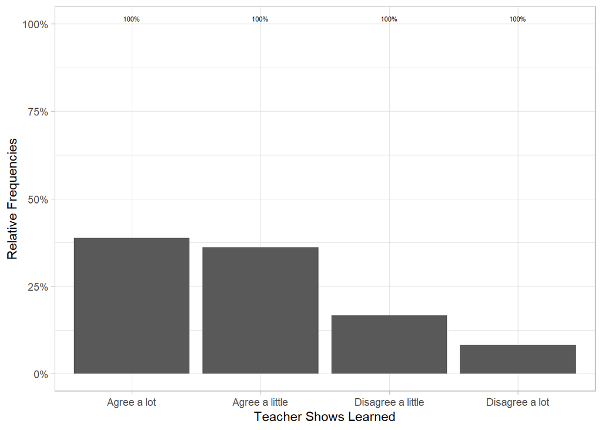

```r
ggplot(data = data.short1, aes (x = BSBM18G)) +
  geom_bar(aes(y=..count../sum(..count..))) +
  labs(x = "Teacher Shows Learned") +
  scale_y_continuous(labels=scales::percent) +
  ylab("Relative Frequencies") +
  geom_text(aes( label = scales::percent(..prop..),
  y= ..prop.. ), stat= "count", vjust = -.5, size = 2) +
  theme(axis.title = element_text(size = 7), axis.text = element_text(size = 7)) +
  theme_light()
```

## BSBM18H - Different Things To Help

```r
summary(data.short1$BSBM18H)
```

```
##       Agree a lot    Agree a little Disagree a little    Disagree a lot
##              4337              2783              1249               644
```

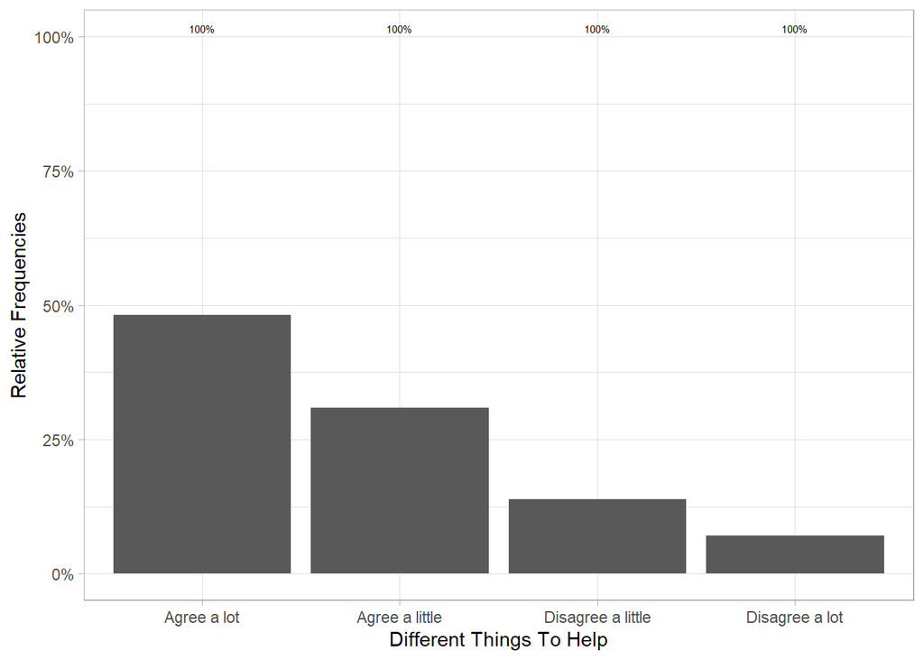

```r
ggplot(data = data.short1, aes (x = BSBM18H)) +
  geom_bar(aes(y=..count../sum(..count..))) +
  labs(x = "Different Things To Help") +
  scale_y_continuous(labels=scales::percent) +
  ylab("Relative Frequencies") +
  geom_text(aes( label = scales::percent(..prop..),
  y= ..prop.. ), stat= "count", vjust = -.5, size = 2) +
  theme(axis.title = element_text(size = 7), axis.text = element_text(size = 7)) +
  theme_light()
```

## BSBM18I - Tells How To Do Better

```r
summary(data.short1$BSBM18I)
```

```
##       Agree a lot    Agree a little Disagree a little    Disagree a lot
##              4570              2763              1078               602
```

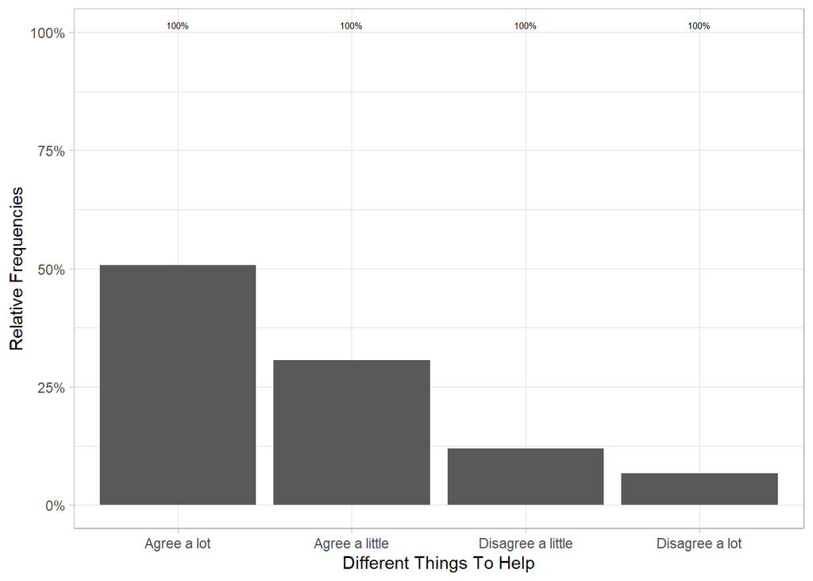

```r
ggplot(data = data.short1, aes (x = BSBM18I)) +
  geom_bar(aes(y=..count../sum(..count..))) +
  labs(x = "Different Things To Help") +
  scale_y_continuous(labels=scales::percent) +
  ylab("Relative Frequencies") +
  geom_text(aes( label = scales::percent(..prop..),
  y= ..prop.. ), stat= "count", vjust = -.5, size = 2) +
  theme(axis.title = element_text(size = 7), axis.text = element_text(size = 7)) +
  theme_light()
```

## BSBM18J - Teacher Listens

```r
summary(data.short1$BSBM18J)
```

```
##       Agree a lot    Agree a little Disagree a little    Disagree a lot
##              4478              2732              1100               703
```

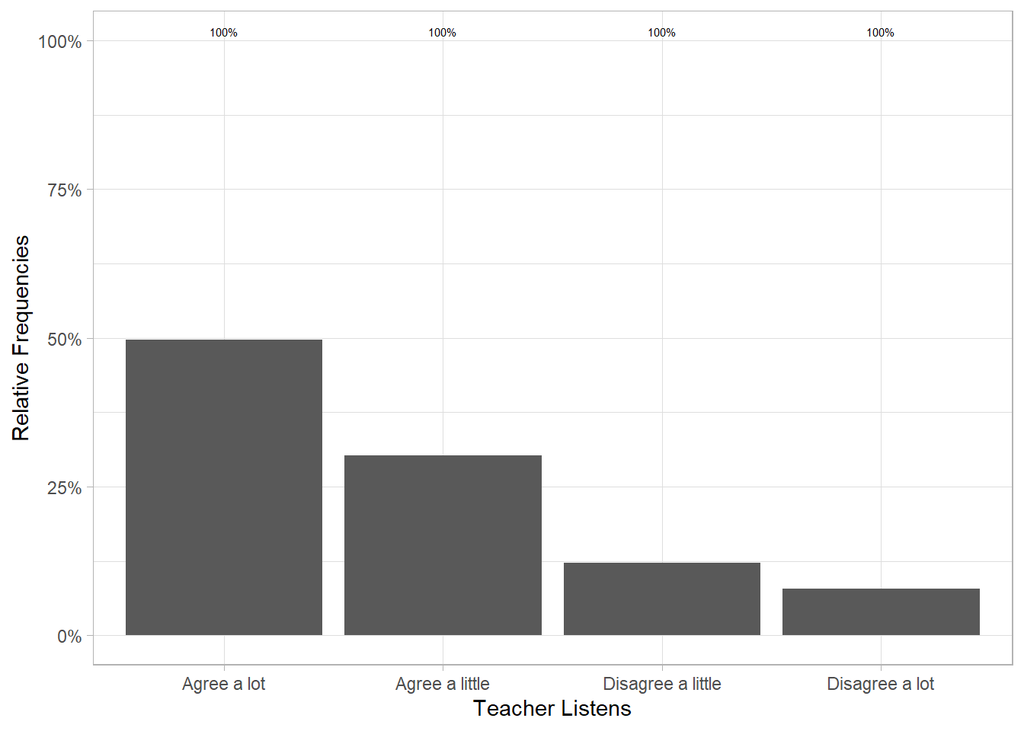

```r
ggplot(data = data.short1, aes (x = BSBM18J)) +
  geom_bar(aes(y=..count../sum(..count..))) +
  labs(x = "Teacher Listens") +
  scale_y_continuous(labels=scales::percent) +
  ylab("Relative Frequencies") +
  geom_text(aes( label = scales::percent(..prop..),
  y= ..prop.. ), stat= "count", vjust = -.5, size = 2) +
  theme(axis.title = element_text(size = 7), axis.text = element_text(size = 7)) +
  theme_light()
```

## BSBM19A - Usually Do Well In Math

```r
summary(data.short1$BSBM19A)
```

```
##       Agree a lot    Agree a little Disagree a little    Disagree a lot
##              3847              3478              1108               580
```

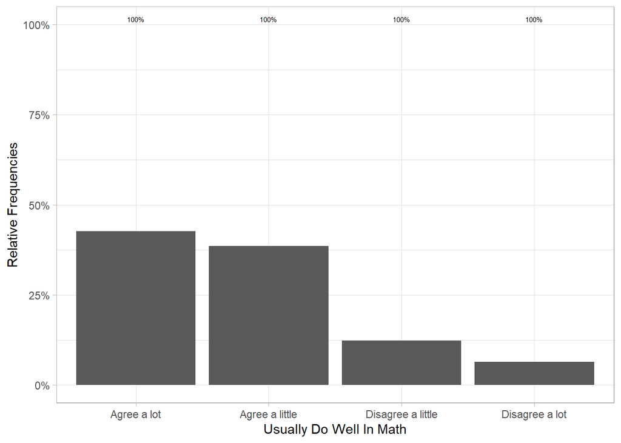

```r
ggplot(data = data.short1, aes (x = BSBM19A)) +
  geom_bar(aes(y=..count../sum(..count..))) +
  labs(x = "Usually Do Well In Math") +
  scale_y_continuous(labels=scales::percent) +
  ylab("Relative Frequencies") +
  geom_text(aes( label = scales::percent(..prop..),
  y= ..prop.. ), stat= "count", vjust = -.5, size = 2) +
  theme(axis.title = element_text(size = 7), axis.text = element_text(size = 7)) +
  theme_light()
```

## BSBM19B - Mathematics Is More Difficult

```r
summary(data.short1$BSBM19B)
```

```
##       Agree a lot    Agree a little Disagree a little    Disagree a lot
##              1280              2127              2864              2742
```

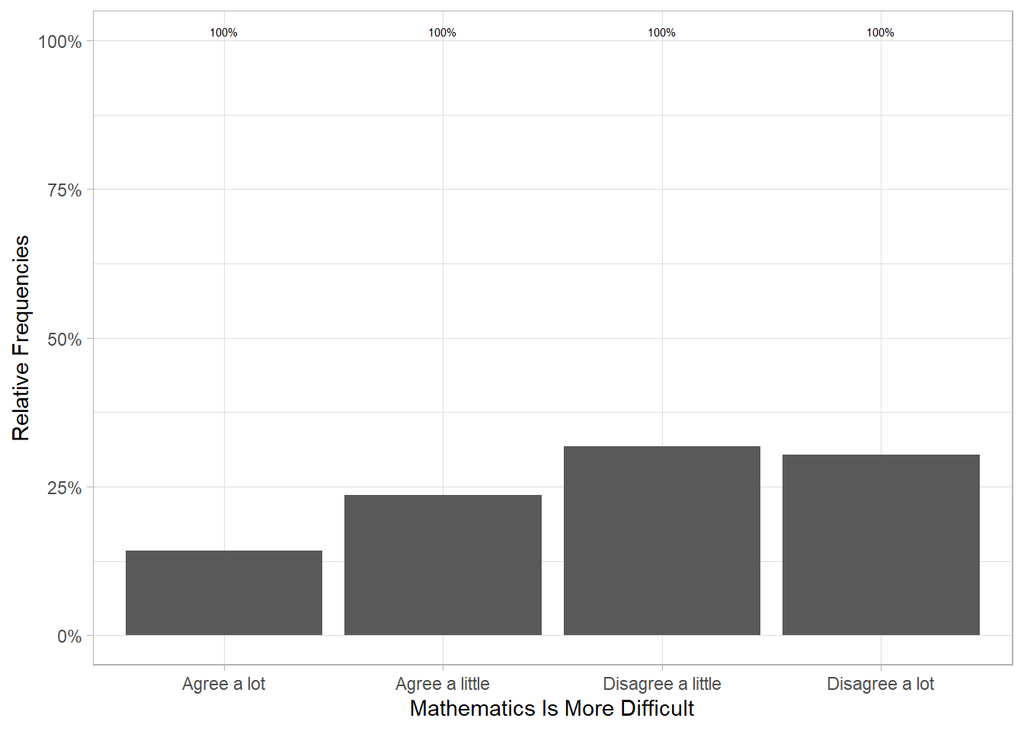

```r
ggplot(data = data.short1, aes (x = BSBM19B)) +
  geom_bar(aes(y=..count../sum(..count..))) +
  labs(x = "Mathematics Is More Difficult") +
  scale_y_continuous(labels=scales::percent) +
  ylab("Relative Frequencies") +
  geom_text(aes( label = scales::percent(..prop..),
  y= ..prop.. ), stat= "count", vjust = -.5, size = 2) +
  theme(axis.title = element_text(size = 7), axis.text = element_text(size = 7)) +
  theme_light()
```

## BSBM19C - Mathematics Not My Strength

```r
summary(data.short1$BSBM19C)
```

```
##       Agree a lot    Agree a little Disagree a little    Disagree a lot
##              2076              2089              2283              2565
```

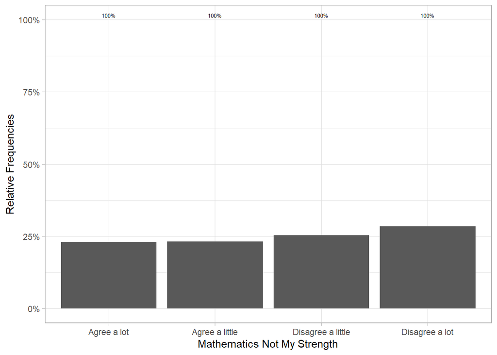

```r
ggplot(data = data.short1, aes (x = BSBM19C)) +
  geom_bar(aes(y=..count../sum(..count..))) +
  labs(x = "Mathematics Not My Strength") +
  scale_y_continuous(labels=scales::percent) +
  ylab("Relative Frequencies") +
  geom_text(aes( label = scales::percent(..prop..),
  y= ..prop.. ), stat= "count", vjust = -.5, size = 2) +
  theme(axis.title = element_text(size = 7), axis.text = element_text(size = 7)) +
  theme_light()
```

## BSBM19D - Learn Quickly In Mathematics

```r
summary(data.short1$BSBM19D)
```

```
##       Agree a lot    Agree a little Disagree a little    Disagree a lot
##              2599              3252              2172               990
```

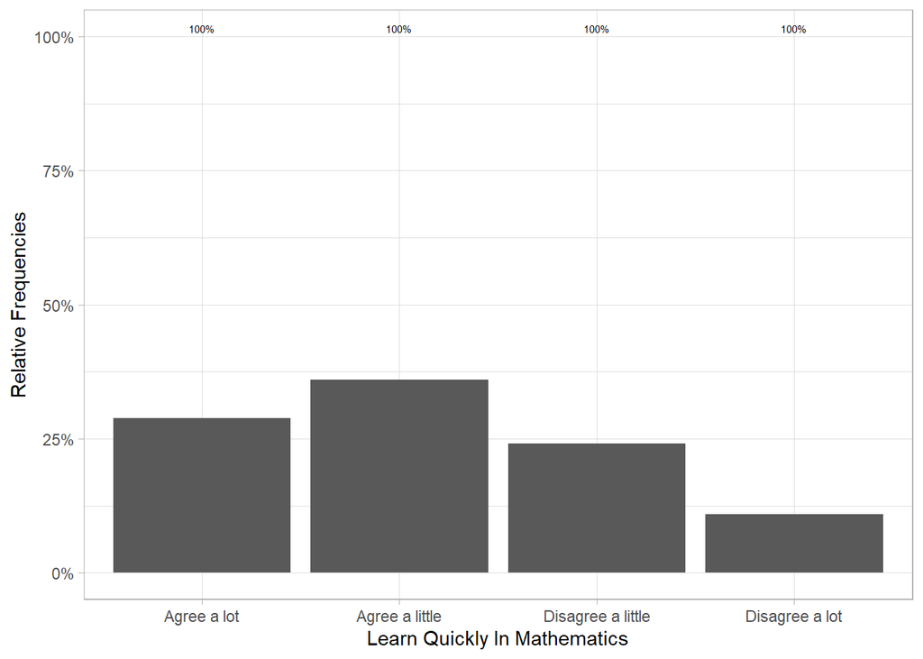

```r
ggplot(data = data.short1, aes (x = BSBM19D)) +
  geom_bar(aes(y=..count../sum(..count..))) +
  labs(x = "Learn Quickly In Mathematics") +
  scale_y_continuous(labels=scales::percent) +
  ylab("Relative Frequencies") +
  geom_text(aes( label = scales::percent(..prop..),
  y= ..prop.. ), stat= "count", vjust = -.5, size = 2) +
  theme(axis.title = element_text(size = 7), axis.text = element_text(size = 7)) +
  theme_light()
```

## BSBM19E - Math Makes Nervous

```r
summary(data.short1$BSBM19E)
```

```
##       Agree a lot    Agree a little Disagree a little    Disagree a lot
##              1167              2209              2755              2882
```

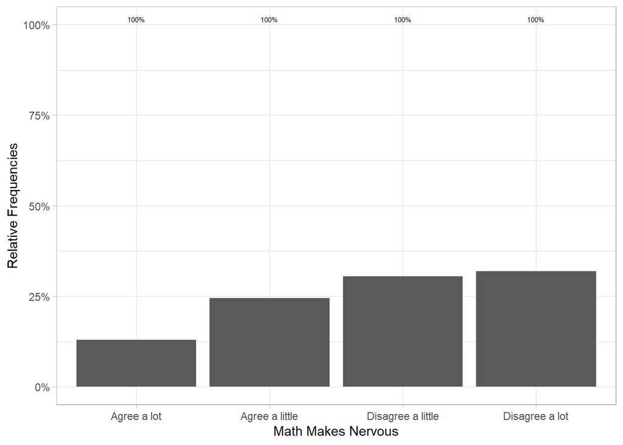

```r
ggplot(data = data.short1, aes (x = BSBM19E)) +
  geom_bar(aes(y=..count../sum(..count..))) +
  labs(x = "Math Makes Nervous") +
  scale_y_continuous(labels=scales::percent) +
  ylab("Relative Frequencies") +
  geom_text(aes( label = scales::percent(..prop..),
  y= ..prop.. ), stat= "count", vjust = -.5, size = 2) +
  theme(axis.title = element_text(size = 7), axis.text = element_text(size = 7)) +
  theme_light()
```

## BSMMAT01 - 1st Plausible Value Mathematics

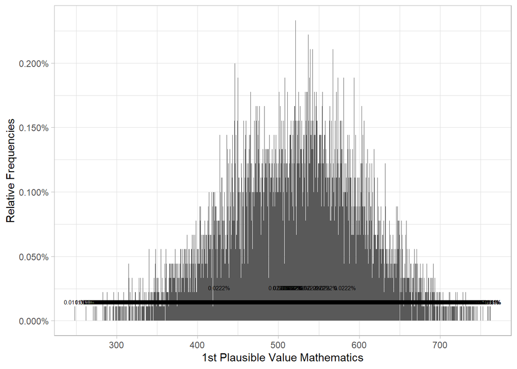

```r
data.short1$BSMMAT01 <- as.numeric(as.character(data.short1$BSMMAT01))

ggplot(data = data.short1, aes (x = as.numeric(as.character(BSMMAT01)), y = (..count..)/sum(..count..))) +
  geom_histogram(bins = 10, binwidth = 0.25) +
  labs(x = "1st Plausible Value Mathematics") +
  scale_y_continuous(labels=scales::percent) +
  ylab("Relative Frequencies") +
  geom_text(aes( label = scales::percent(..prop..),
  y= ..prop.. ), stat= "count", vjust = -.5, size = 2) +
  theme(axis.title = element_text(size = 7), axis.text = element_text(size = 7)) +
  theme_light()
```

## ITSEX - Sex of Students

```r
summary(data.short1$ITSEX)
```

```
## Female   Male
##   4596   4417
```

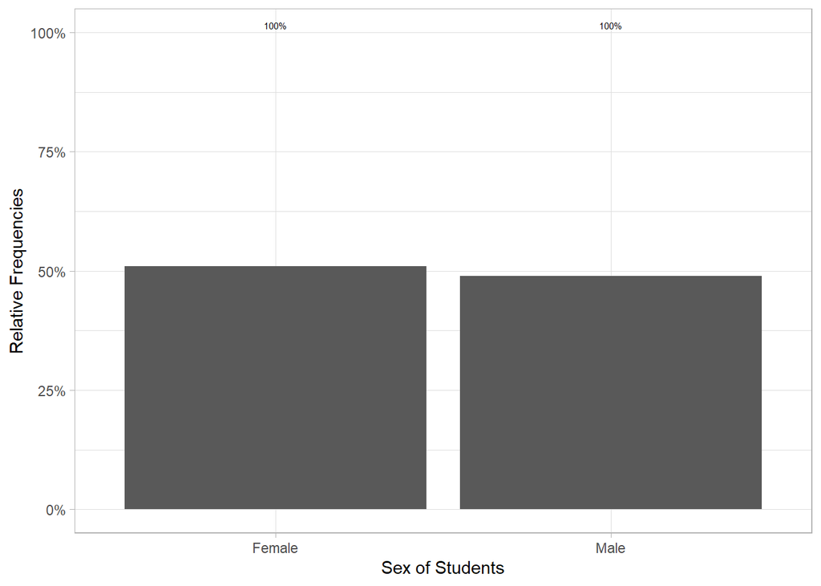

```r
ggplot(data = data.short1, aes (x = ITSEX)) +
  geom_bar(aes(y=..count../sum(..count..))) +
  labs(x = "Sex of Students") +
  scale_y_continuous(labels=scales::percent) +
  ylab("Relative Frequencies") +
  geom_text(aes( label = scales::percent(..prop..),
  y= ..prop.. ), stat= "count", vjust = -.5, size = 2) +
  theme(axis.title = element_text(size = 7), axis.text = element_text(size = 7)) +
  theme_light()
```

## BSDGEDUP - Parents’ Highest Education Level

```r
summary(data.short1$BSDGEDUP)
```

```
##                       University or Higher
##                                       3654
##          Post-secondary but not University
##                                       1063
##                            Upper Secondary
##                                       1828
##                            Lower Secondary
##                                        475
## Some Primary, Lower Secondary or No School
##                                        206
##                                 Don't Know
##                                       1787
```

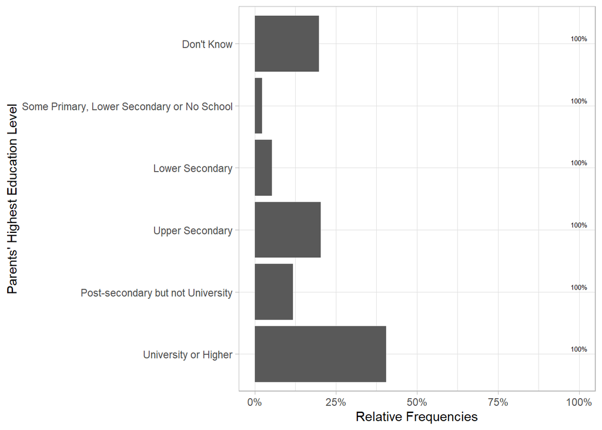

```r
ggplot(data = data.short1, aes (x = BSDGEDUP)) +
  geom_bar(aes(y=..count../sum(..count..))) +
  labs(x = "Parents' Highest Education Level") +
  scale_y_continuous(labels=scales::percent) +
  ylab("Relative Frequencies") +
  geom_text(aes( label = scales::percent(..prop..),
  y= ..prop.. ), stat= "count", vjust = -.5, size = 2) +
  theme(axis.title = element_text(size = 7), axis.text = element_text(size = 7)) +
  theme_light() + coord_flip()
```

## BSBG10A - Born in USA

```r
summary(data.short1$BSBG10A)
```

```
##  Yes   No
## 8501  512
```

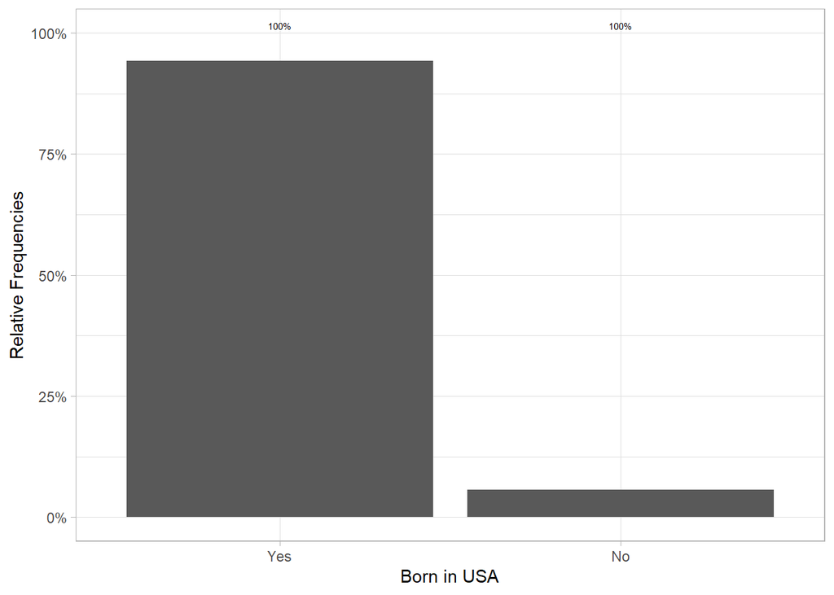

```r
ggplot(data = data.short1, aes (x = BSBG10A)) +
  geom_bar(aes(y=..count../sum(..count..))) +
  labs(x = "Born in USA") +
  scale_y_continuous(labels=scales::percent) +
  ylab("Relative Frequencies") +
  geom_text(aes( label = scales::percent(..prop..),
  y= ..prop.. ), stat= "count", vjust = -.5, size = 2) +
  theme(axis.title = element_text(size = 7), axis.text = element_text(size = 7)) +
  theme_light()
```

# EFA

## Correlation

```r
library(polycor)
library(corrplot)
dat.cor <- hetcor(data.efa)
```

Uploading packages which are needed. Finding correlation between variables.

## Plot

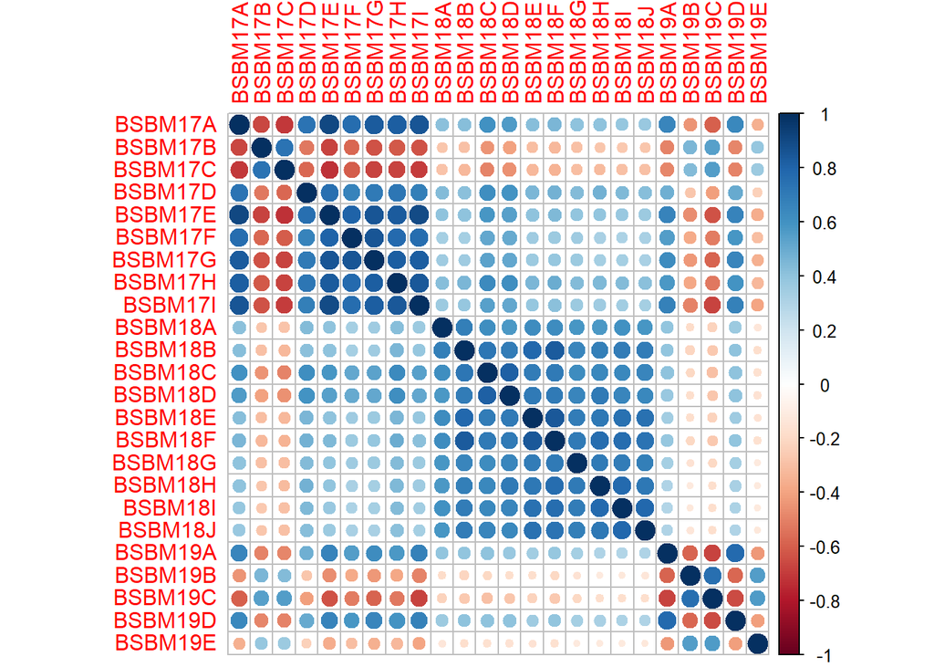

```r
corrplot(dat.cor$correlations)
```

The plot above shows correlations between variables presented in the data. It is clear that there are areas where the correlations between variables of the same “number group”, for example 17 or 18, are high enough to consider them to be associated with one particular trajectory. Thus, I can make a conclusion, that these variables are appropriate to be chosen for further Explonatory Factor Analysis.

## Number of Factors

```r
library(psych)
```

I uploaded the package which is necessary for further analysis.

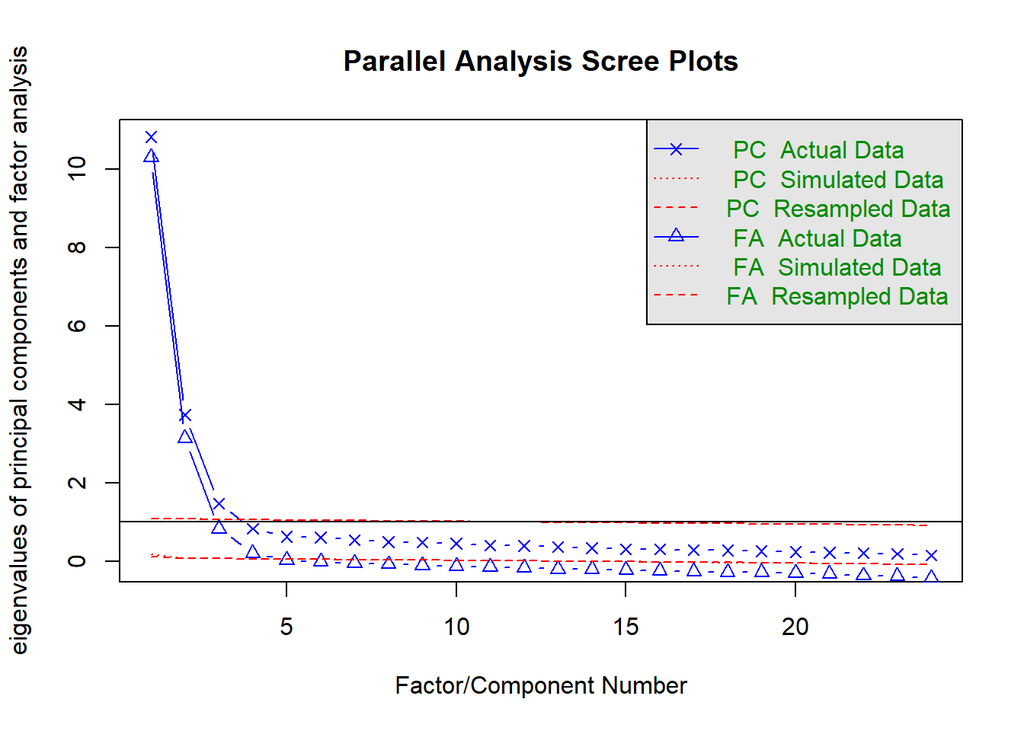

```
## Parallel analysis suggests that the number of factors =  4  and the number of components =  3
```

```r
data.efa1 <- as.data.frame(lapply(data.efa, as.numeric))
fa.parallel(data.efa1, fa="both", n.iter=100 )
```

In order to make a scree plot and find the appropriate number of factors I converted all of the variable in my dataset into numeric.

The maximum number of factors is 4, and the number of components is 3, each additional factor or component does not explain more variance.

## Model

### Creating a model

```r
m1 <- fa(data.efa1, nfactors = 3, rotate = "varimax", fm = "ml", cor = "mixed")
```

- *nfactors* = 3 (After some trials, I have found that this is the optimal number of factors to make the good model fit)
- *rotate* = “varimax” (Rotation is needed in this model, because without it SS loadings on one factor are very high in comparison to other factors. I have chosen this type of rotation under the assumption that variables are correlated.)
- *fm* = “ml” (I have chosen Maximum Likelihood factor extraction technique, assuming multivariate normal distribution)
- *cor* = “mixed” (This is done in order to make further analysis with factor scores)

### Loadings

```r
print(m1$loadings,cutoff = 0.5)
```

```
##
## Loadings:
##         ML2    ML1    ML3
## BSBM17A         0.831
## BSBM17B        -0.596
## BSBM17C        -0.661
## BSBM17D         0.714
## BSBM17E         0.860
## BSBM17F         0.805
## BSBM17G         0.842
## BSBM17H         0.809
## BSBM17I         0.813
## BSBM18A  0.676
## BSBM18B  0.842
## BSBM18C  0.721
## BSBM18D  0.732
## BSBM18E  0.868
## BSBM18F  0.880
## BSBM18G  0.761
## BSBM18H  0.817
## BSBM18I  0.834
## BSBM18J  0.817
## BSBM19A                0.607
## BSBM19B               -0.806
## BSBM19C               -0.794
## BSBM19D                0.577
## BSBM19E               -0.592
##
##                  ML2   ML1   ML3
## SS loadings    7.096 6.777 3.197
## Proportion Var 0.296 0.282 0.133
## Cumulative Var 0.296 0.578 0.711
```

Factor loadings shows that all of the variables has only 1 factor which explains them. I chose to setup cutoff = 0.5 as long it shows only variables which are significant in my model. We can see that there are no “double-loading” variables, thus, I may conclude that this is a simple structure.

### Adequacy Test

```r
m1
```

```
## Factor Analysis using method =  ml
## Call: fa(r = data.efa1, nfactors = 3, rotate = "varimax", fm = "ml",
##     cor = "mixed")
## Standardized loadings (pattern matrix) based upon correlation matrix
##           ML2   ML1   ML3   h2    u2 com
## BSBM17A  0.28  0.83  0.30 0.86 0.138 1.5
## BSBM17B -0.18 -0.60 -0.35 0.51 0.487 1.8
## BSBM17C -0.20 -0.66 -0.31 0.58 0.423 1.6
## BSBM17D  0.37  0.71  0.11 0.66 0.340 1.6
## BSBM17E  0.25  0.86  0.32 0.91 0.091 1.5
## BSBM17F  0.21  0.80  0.21 0.74 0.265 1.3
## BSBM17G  0.21  0.84  0.28 0.83 0.167 1.4
## BSBM17H  0.34  0.81  0.21 0.82 0.182 1.5
## BSBM17I  0.22  0.81  0.39 0.86 0.138 1.6
## BSBM18A  0.68  0.21  0.13 0.52 0.481 1.3
## BSBM18B  0.84  0.15  0.18 0.77 0.233 1.2
## BSBM18C  0.72  0.45  0.06 0.72 0.276 1.7
## BSBM18D  0.73  0.42  0.04 0.72 0.285 1.6
## BSBM18E  0.87  0.17  0.12 0.80 0.203 1.1
## BSBM18F  0.88  0.19  0.16 0.83 0.165 1.2
## BSBM18G  0.76  0.21  0.08 0.63 0.373 1.2
## BSBM18H  0.82  0.20  0.04 0.71 0.292 1.1
## BSBM18I  0.83  0.17  0.05 0.73 0.274 1.1
## BSBM18J  0.82  0.16  0.06 0.70 0.303 1.1
## BSBM19A  0.23  0.47  0.61 0.65 0.354 2.2
## BSBM19B -0.05 -0.23 -0.81 0.71 0.294 1.2
## BSBM19C -0.07 -0.41 -0.79 0.81 0.192 1.5
## BSBM19D  0.25  0.49  0.58 0.63 0.368 2.3
## BSBM19E -0.05 -0.20 -0.59 0.39 0.606 1.2
##
##                        ML2  ML1  ML3
## SS loadings           7.10 6.78 3.20
## Proportion Var        0.30 0.28 0.13
## Cumulative Var        0.30 0.58 0.71
## Proportion Explained  0.42 0.40 0.19
## Cumulative Proportion 0.42 0.81 1.00
##
## Mean item complexity =  1.4
## Test of the hypothesis that 3 factors are sufficient.
##
## The degrees of freedom for the null model are  276  and the objective function was  25 with Chi Square of  225050.2
## The degrees of freedom for the model are 207  and the objective function was  1.49
##
## The root mean square of the residuals (RMSR) is  0.02
## The df corrected root mean square of the residuals is  0.03
##
## The harmonic number of observations is  9013 with the empirical chi square  2784.73  with prob <  0
## The total number of observations was  9013  with Likelihood Chi Square =  13401.56  with prob <  0
##
## Tucker Lewis Index of factoring reliability =  0.922
## RMSEA index =  0.084  and the 90 % confidence intervals are  0.083 0.085
## BIC =  11516.54
## Fit based upon off diagonal values = 1
## Measures of factor score adequacy
##                                                    ML2  ML1  ML3
## Correlation of (regression) scores with factors   0.98 0.97 0.92
## Multiple R square of scores with factors          0.95 0.94 0.85
## Minimum correlation of possible factor scores     0.91 0.87 0.70
```

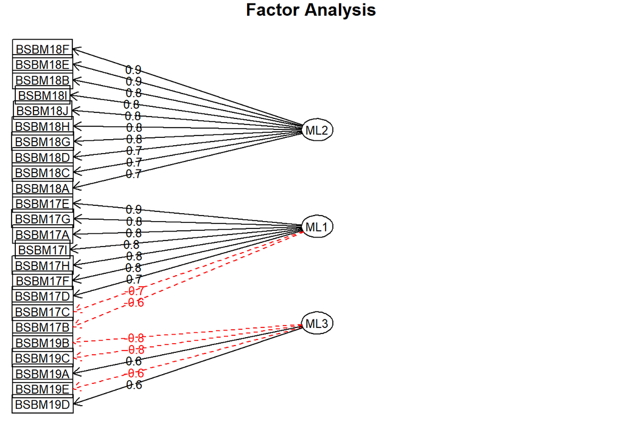

```r
fa.diagram(m1)
```

The above plot shows how variables are distibuted to factors.

## Chronbach’s alpha

```r
ML1 <- as.data.frame(data.efa1[c("BSBM17A", "BSBM17B", "BSBM17C", "BSBM17D", "BSBM17E", "BSBM17F", "BSBM17G", "BSBM17H", "BSBM17I")])
alpha(ML1, check.keys = TRUE)
```

```
##
## Reliability analysis
## Call: alpha(x = ML1, check.keys = TRUE)
##
##   raw_alpha std.alpha G6(smc) average_r S/N     ase mean   sd median_r
##       0.94      0.94    0.94      0.65  17 0.00089  2.4 0.88     0.64
##
##  lower alpha upper     95% confidence boundaries
## 0.94 0.94 0.95
##
##  Reliability if an item is dropped:
##          raw_alpha std.alpha G6(smc) average_r S/N alpha se  var.r med.r
## BSBM17A       0.93      0.93    0.93      0.64  14  0.00106 0.0101  0.63
## BSBM17B-      0.94      0.94    0.94      0.68  17  0.00087 0.0078  0.68
## BSBM17C-      0.94      0.94    0.94      0.67  16  0.00092 0.0106  0.68
## BSBM17D       0.94      0.94    0.94      0.67  16  0.00094 0.0095  0.68
## BSBM17E       0.93      0.93    0.93      0.63  14  0.00109 0.0088  0.62
## BSBM17F       0.94      0.94    0.94      0.65  15  0.00099 0.0102  0.63
## BSBM17G       0.93      0.93    0.93      0.64  14  0.00105 0.0098  0.63
## BSBM17H       0.93      0.93    0.94      0.64  14  0.00104 0.0106  0.63
## BSBM17I       0.93      0.93    0.93      0.64  14  0.00105 0.0100  0.63
##
##  Item statistics
##             n raw.r std.r r.cor r.drop mean   sd
## BSBM17A  9013  0.88  0.88  0.87   0.85  2.2 1.02
## BSBM17B- 9013  0.72  0.72  0.67   0.65  2.4 1.10
## BSBM17C- 9013  0.76  0.76  0.72   0.70  2.6 1.06
## BSBM17D  9013  0.75  0.76  0.72   0.69  2.1 0.96
## BSBM17E  9013  0.91  0.91  0.91   0.88  2.3 1.07
## BSBM17F  9013  0.82  0.82  0.80   0.77  2.7 0.98
## BSBM17G  9013  0.88  0.88  0.87   0.84  2.5 1.05
## BSBM17H  9013  0.87  0.87  0.85   0.83  2.6 1.06
## BSBM17I  9013  0.87  0.87  0.86   0.83  2.6 1.19
##
## Non missing response frequency for each item
##            1    2    3    4 miss
## BSBM17A 0.28 0.38 0.18 0.16    0
## BSBM17B 0.21 0.26 0.26 0.26    0
## BSBM17C 0.24 0.31 0.25 0.20    0
## BSBM17D 0.29 0.38 0.22 0.11    0
## BSBM17E 0.28 0.34 0.19 0.19    0
## BSBM17F 0.13 0.28 0.34 0.25    0
## BSBM17G 0.20 0.31 0.26 0.23    0
## BSBM17H 0.19 0.28 0.28 0.25    0
## BSBM17I 0.27 0.21 0.20 0.31    0
```

For factor ML1 Cronbach’s alpha (0.94) is bigger than 0.7, which indicates very good reliability.

```r
ML2 <- as.data.frame(data.efa1[c("BSBM18A", "BSBM18B", "BSBM18C", "BSBM18D", "BSBM18E", "BSBM18F", "BSBM18G", "BSBM18H", "BSBM18I", "BSBM18J")])
alpha(ML2, check.keys = TRUE)
```

```
##
## Reliability analysis
## Call: alpha(x = ML2, check.keys = TRUE)
##
##   raw_alpha std.alpha G6(smc) average_r S/N     ase mean   sd median_r
##       0.94      0.94    0.94       0.6  15 0.00097  1.9 0.74      0.6
##
##  lower alpha upper     95% confidence boundaries
## 0.93 0.94 0.94
##
##  Reliability if an item is dropped:
##         raw_alpha std.alpha G6(smc) average_r S/N alpha se  var.r med.r
## BSBM18A      0.94      0.94    0.94      0.62  15   0.0010 0.0031  0.61
## BSBM18B      0.93      0.93    0.93      0.59  13   0.0011 0.0057  0.60
## BSBM18C      0.93      0.93    0.93      0.60  13   0.0011 0.0058  0.60
## BSBM18D      0.93      0.93    0.93      0.60  13   0.0011 0.0056  0.61
## BSBM18E      0.93      0.93    0.93      0.59  13   0.0011 0.0052  0.60
## BSBM18F      0.93      0.93    0.93      0.58  13   0.0011 0.0047  0.60
## BSBM18G      0.93      0.93    0.93      0.60  14   0.0011 0.0063  0.61
## BSBM18H      0.93      0.93    0.93      0.59  13   0.0011 0.0059  0.60
## BSBM18I      0.93      0.93    0.93      0.59  13   0.0011 0.0057  0.60
## BSBM18J      0.93      0.93    0.93      0.60  13   0.0011 0.0059  0.60
##
##  Item statistics
##            n raw.r std.r r.cor r.drop mean   sd
## BSBM18A 9013  0.66  0.68  0.62   0.60  1.5 0.70
## BSBM18B 9013  0.83  0.83  0.81   0.78  1.9 0.94
## BSBM18C 9013  0.79  0.79  0.77   0.74  2.1 0.95
## BSBM18D 9013  0.79  0.79  0.76   0.73  2.2 1.00
## BSBM18E 9013  0.85  0.84  0.83   0.80  1.9 0.98
## BSBM18F 9013  0.85  0.85  0.84   0.81  1.8 0.95
## BSBM18G 9013  0.77  0.77  0.74   0.72  1.9 0.94
## BSBM18H 9013  0.81  0.81  0.78   0.76  1.8 0.93
## BSBM18I 9013  0.81  0.81  0.79   0.76  1.7 0.91
## BSBM18J 9013  0.80  0.80  0.77   0.75  1.8 0.94
##
## Non missing response frequency for each item
##            1    2    3    4 miss
## BSBM18A 0.62 0.30 0.06 0.02    0
## BSBM18B 0.44 0.33 0.15 0.08    0
## BSBM18C 0.32 0.38 0.21 0.09    0
## BSBM18D 0.27 0.35 0.25 0.13    0
## BSBM18E 0.42 0.31 0.17 0.09    0
## BSBM18F 0.52 0.28 0.13 0.08    0
## BSBM18G 0.39 0.36 0.17 0.08    0
## BSBM18H 0.48 0.31 0.14 0.07    0
## BSBM18I 0.51 0.31 0.12 0.07    0
## BSBM18J 0.50 0.30 0.12 0.08    0
```

For factor ML2 Cronbach’s alpha (0.94) is bigger than 0.7, which indicates very good reliability.

```r
ML3 <- as.data.frame(data.efa1[c("BSBM19A", "BSBM19B", "BSBM19C", "BSBM19D", "BSBM19E")])
alpha(ML3, check.keys = TRUE)
```

```
##
## Reliability analysis
## Call: alpha(x = ML3, check.keys = TRUE)
##
##   raw_alpha std.alpha G6(smc) average_r S/N    ase mean   sd median_r
##       0.84      0.84    0.83      0.51 5.3 0.0026  2.8 0.79     0.49
##
##  lower alpha upper     95% confidence boundaries
## 0.83 0.84 0.84
##
##  Reliability if an item is dropped:
##          raw_alpha std.alpha G6(smc) average_r S/N alpha se var.r med.r
## BSBM19A-      0.81      0.81    0.77      0.51 4.2   0.0033 0.011  0.49
## BSBM19B       0.80      0.80    0.77      0.50 4.0   0.0035 0.017  0.53
## BSBM19C       0.78      0.78    0.75      0.47 3.6   0.0038 0.014  0.48
## BSBM19D-      0.80      0.80    0.77      0.51 4.1   0.0033 0.011  0.49
## BSBM19E       0.84      0.85    0.82      0.58 5.5   0.0027 0.007  0.56
##
##  Item statistics
##             n raw.r std.r r.cor r.drop mean   sd
## BSBM19A- 9013  0.77  0.79  0.73   0.65  3.2 0.88
## BSBM19B  9013  0.81  0.80  0.74   0.68  2.8 1.03
## BSBM19C  9013  0.85  0.84  0.80   0.74  2.6 1.13
## BSBM19D- 9013  0.78  0.79  0.74   0.65  2.8 0.97
## BSBM19E  9013  0.69  0.68  0.55   0.51  2.8 1.02
##
## Non missing response frequency for each item
##            1    2    3    4 miss
## BSBM19A 0.43 0.39 0.12 0.06    0
## BSBM19B 0.14 0.24 0.32 0.30    0
## BSBM19C 0.23 0.23 0.25 0.28    0
## BSBM19D 0.29 0.36 0.24 0.11    0
## BSBM19E 0.13 0.25 0.31 0.32    0
```

For factor ML3 Cronbach’s alpha (0.84) is bigger than 0.7, which indicates good reliability.

## Naming Factors

- *ML1* “Student’s overall attitude towards math science”
- *ML2* “Teacher’s involvement into studying process”
- *ML3* “Student’s abilities in math”

## Factor Scores

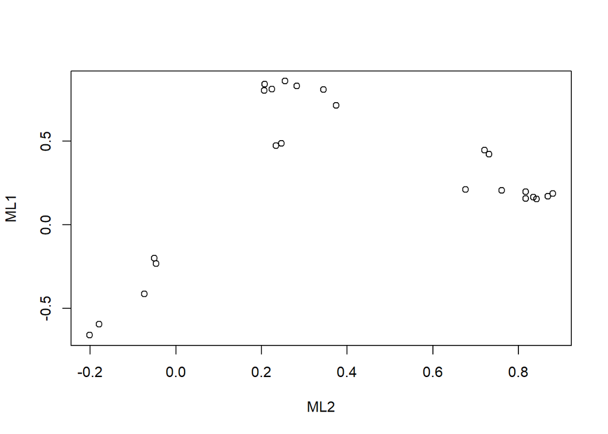

```r
load <- m1$loadings[,1:2]
plot(load)
```

```r
fascores <- as.data.frame(m1$scores)
data.fa <- cbind(data.efa1,fascores)
names(data.fa)
```

```
##  [1] "BSBM17A" "BSBM17B" "BSBM17C" "BSBM17D" "BSBM17E" "BSBM17F" "BSBM17G"
##  [8] "BSBM17H" "BSBM17I" "BSBM18A" "BSBM18B" "BSBM18C" "BSBM18D" "BSBM18E"
## [15] "BSBM18F" "BSBM18G" "BSBM18H" "BSBM18I" "BSBM18J" "BSBM19A" "BSBM19B"
## [22] "BSBM19C" "BSBM19D" "BSBM19E" "ML2"     "ML1"     "ML3"
```

# Regression Analysis

```r
data.full <- cbind(data.reg,fascores)
names(data.full)
```

```
## [1] "BSMMAT01" "ITSEX"    "BSBG10A"  "BSDGEDUP" "ML2"      "ML1"
## [7] "ML3"
```

```r
data.full$BSMMAT01 <- as.numeric(as.character(data.full$BSMMAT01))
```

```r
model.reg <- lm(BSMMAT01 ~ ML2 + ML1 + ML3 + ITSEX + BSBG10A + BSDGEDUP , data = data.full)
summary(model.reg)
```

```
##
## Call:
## lm(formula = BSMMAT01 ~ ML2 + ML1 + ML3 + ITSEX + BSBG10A + BSDGEDUP,
##     data = data.full)
##
## Residuals:
##      Min       1Q   Median       3Q      Max
## -246.672  -45.421    3.336   47.479  280.919
##
## Coefficients:
##                                                    Estimate Std. Error
## (Intercept)                                        541.5228     1.3784
## ML2                                                 -2.6908     0.7145
## ML1                                                -10.5776     0.7535
## ML3                                                -34.8650     0.7850
## ITSEXMale                                           -0.9368     1.4678
## BSBG10ANo                                           -7.2783     3.1821
## BSDGEDUPPost-secondary but not University          -29.2640     2.4268
## BSDGEDUPUpper Secondary                            -35.9313     2.0001
## BSDGEDUPLower Secondary                            -42.4142     3.4095
## BSDGEDUPSome Primary, Lower Secondary or No School -44.0101     4.9939
## BSDGEDUPDon't Know                                 -32.5825     2.0184
##                                                    t value Pr(>|t|)
## (Intercept)                                        392.855  < 2e-16 ***
## ML2                                                 -3.766 0.000167 ***
## ML1                                                -14.038  < 2e-16 ***
## ML3                                                -44.416  < 2e-16 ***
## ITSEXMale                                           -0.638 0.523350
## BSBG10ANo                                           -2.287 0.022206 *
## BSDGEDUPPost-secondary but not University          -12.059  < 2e-16 ***
## BSDGEDUPUpper Secondary                            -17.965  < 2e-16 ***
## BSDGEDUPLower Secondary                            -12.440  < 2e-16 ***
## BSDGEDUPSome Primary, Lower Secondary or No School  -8.813  < 2e-16 ***
## BSDGEDUPDon't Know                                 -16.143  < 2e-16 ***
## ---
## Signif. codes:  0 '***' 0.001 '**' 0.01 '*' 0.05 '.' 0.1 ' ' 1
##
## Residual standard error: 69.46 on 9002 degrees of freedom
## Multiple R-squared:  0.2687, Adjusted R-squared:  0.2679
## F-statistic: 330.7 on 10 and 9002 DF,  p-value: < 2.2e-16
```

The multiple regression model explains the relationship between *6 predictors* and *1 outcome* variable. It is important to notice that scales of ML1, ML2, and ML3 are reversed, which means that the increase in math achievement appears when the value of this predictors is low.

1. Predictors
   - *ML2* (“Teacher’s involvement into studying process”): With the increase by 1 in ML2 factor score, the value of the intercept decreases by 2.7. It means that, deeper involvement of teacher into studiyng increases the math achievement of a student.
   - *ML1* (“Student’s overall attitude towards math science”): With the increase by 1 in ML1 factor score, the value of the intercept decreases by 10.6.It means that, positive attitude towards math science increases the math achievement of a student.
   - *ML3* (“Student’s abilities in math”): With the increase by 1 in ML3 factor score, the value of the intercept decreases by 34.9. It means that, higher abilities in math science increase the math achievement of a student.
   - *ITSEX* (“Student’s gender”): The estimate of the predictor is not significant, it means that math achievement does not strictly depends on gender of a student.
   - *BSBG10A* (“Born in USA”): Even that this predictor is not highly significant, it is important to notice that if a student was born in USA, he or she has slightly higher math achievements.
   - *BSDGEDUP* (“Education of parents”): The overall tendency shows that higher level of education of parents has positive influence on math achievement of a student.
2. Outcome
   - *BSMMAT01* (“Math Achievement”): The value of math achievement (intercept) is equal to 541.5 when predictors are equal to 0.
3. Model
   - The p-value is less than 0.05, which indicates that overall model is significant. The model explains *26.8 percent* of total variance.

## Multicollinearity Checking

```r
library(car)
vif(model.reg)
```

```
##              GVIF Df GVIF^(1/(2*Df))
## ML2      1.007128  1        1.003558
## ML1      1.030269  1        1.015022
## ML3      1.041120  1        1.020353
## ITSEX    1.005947  1        1.002969
## BSBG10A  1.013630  1        1.006792
## BSDGEDUP 1.036201  5        1.003562
```

According to the results above, the model has no problems with estimating the coefficient. The value of each predictor does not show that this predictor is related to other predictors.